# Time Series II

73-374 Econometrics II

## Today

- Working with time series
- Regression with dependent data
- Inference under serial correlation
- Ensuring data is stationary
  - Trends, Seasonality
- Covered in Ch 10-12 of Wooldridge

## Time Series

- Time series present another design for data
  - Series $(Y_t,X_t)$ $t=1\ldots T$ of ordered observations
- Serial correlation makes usual inference difficult
  - $Cov(Y_t,Y_{t+h})\neq 0$
- But can model serial correlation to describe properties of data
- Approach 1: finite sample properties via strict exogeneity
  - Can do regressions using time series data and rely on finite sample properties
- Approach 2: asymptotic theory under weak dependence
  - Weakly dependent series satisfy modified LLN and CLT
  - Use this to show consistency and asymptotic normality of regression with dependent data
- When the future is “like” the past and historical events are like present ones, we can use past to learn about future
- True for i.i.d. data, stable ARMA processes, many more
- Can fail if future fundamentally different from past

## Stationarity and Weak Dependence: Review

- (Second order) **Stationarity**
  - $E[Y_{t}]=E[Y_{s}]$ for all $t$, $s$
  - $Cov(Y_{t},Y_{t+h})=Cov(Y_{s},Y_{s+h})$ for all $t$, $s$
- **Weak dependence**
  - $Cov(Y_t,Y_{t+h})\rightarrow 0$ as $h\rightarrow \infty$
  - $\sum_{h=-\infty}^{\infty}|Cov(Y_t,Y_{t+h})|<\infty$
- Stationarity and weak dependence imply
  - **Ergodic Theorem** (law of large numbers for time series)
    $$\frac{1}{T}\sum_{t=1}^{T}y_t\overset{p}{\rightarrow}E[y_t]$$
  - Time series **Central limit theorem**
    $$\frac{1}{\sqrt{T}}\sum_{t=1}^{T}(y_t-E[y_t])\overset{d}{\rightarrow}N(0,\Sigma)$$
    $$\Sigma=\sum_{h=-\infty}^{\infty}Cov(y_t,y_{t+h})=Var(Y_t)+2\sum_{h=1}^{\infty}Cov(y_t,y_{t+h})$$

## Time Series Regression: Assumptions

- (TS.1’) Linear Model $(X_t,Y_t)$ drawn from model $Y_t=X_t^{\prime}\beta+u_t$ and satisfy stationarity and weak dependence
- (TS.2’) No perfect multicollinearity of $X_t$
- (TS.3’) Contemporaneous exogeneity $E[u_t|X_t]=0 \forall t$
- or (TS 3’’) $Cov(X_t,u_t)=0$
- (TS.4’) Comtemporaneous homoskedasticity: $Var(u_t|X_t)=\sigma^2$ $\forall\ t$
- (TS.5’) No serial correlation $E[u_tu_s|X_t,X_s]=0$ $\forall\ t\neq s$

## Time Series Regression: Results

- Under (TS.1’),(TS.2’),(TS.3’‘) (or (TS.3’), which implies (TS.3’’)), have consistency:
  $$\widehat{\beta}\overset{p}{\rightarrow}\beta$$
- Under (TS.1’)-(TS.5’) have asymptotic normality with usual variance formula
  $$\sqrt{T}(\widehat{\beta}-\beta)\overset{d}{\rightarrow}N(0,\sigma^2(E[X_tX_t^\prime])^{-1})$$
- Inference is exactly standard: t-statistics, Wald tests, CIs, etc
- With serial correlation or heteroskedasticity, consistent but need modified standard errors
  - Rely on time series CLT

## Inference in Regression with dependent errors

- Homoskedasticity assumption not critical
  - Heteroskedasticity can be handled by using usual sandwich variance formula
- Zero serial correlation in errors $E[u_tu_s|X_s,X_t]=0$ still needed
- Strong assumption: given predictor variables, future values of outcome completely uncorrelated with past values
- This might be true if we have included any past variables that are related to outcome
  - May not want to or be able to include all relevant predictors
- Don’t need 0 serial correlation for consistency, normality
- If $u_t$ stationary and weakly dependent, OLS asymptototically normal, with a variance that depends on correlation in errors
- Follows from weakly dependent CLT
- If we can estimate the variance, can perform t and Wald tests with new variance estimator

## Variance estimation under autocorrelation

- Asymptotic variance of $\widehat{\beta}_{OLS}$ when $u_t$ serially correlated follows from usual calculations: $\sqrt{T}(\widehat{\beta}-\beta)=$
  $$(\frac{1}{T}\sum_{t=1}^{T}X_tX_t^{\prime})^{-1}\frac{1}{\sqrt{T}}\sum_{t=1}^{T}X_tu_t\overset{d}{\rightarrow}N(0,E[X_tX_t^\prime]^{-1}\Sigma E[X_tX_t^\prime]^{-1})$$
- $\frac{1}{T}\sum_{t=1}^{T}X_tX_t^{\prime}\overset{p}{\rightarrow}E[X_tX_t^\prime]$ by ergodic theorem
- $\frac{1}{\sqrt{T}}\sum_{t=1}^{T}X_tu_t\overset{d}{\rightarrow}N(0,\Sigma)$ by weak dependent CLT
- $\Sigma=Var(X_tu_t)+2Cov(X_tu_t,X_{t+1}u_{t+1})+2Cov(X_tu_t,X_{t+2}u_{t+2})+2Cov(X_tu_t,X_{t+3}u_{t+3})+\ldots$ long run variance
- First part estimated by sample mean, but estimating second part hard since it is infinite sum
- 2 options: come up with model for serial correlation, or estimate $\infty$ sum directly

## Modeling Residual Serial Correlation

- Can estimate long run variance if we have a model of serial correlation in errors
- E.g. $u_t=\rho u_{t-1}+e_{t}$, $e_t\sim i.i.d.(0,\sigma_e^2)$ independent of $X$ then $Cov(u_t,u_{t+h})=\rho^h\sigma_e^2$
- One parameter, can be estimated by two step procedure
  - Regress $Y_t$ on $X_t$ to get residuals $\widehat{u}_t$
  - Regress $\widehat{u}_t$ on $\widehat{u}_{t-1}$ to get $\widehat{\rho}$
- With $\widehat{\rho}$, can use it to run weighted regression which eliminates serial correlation
- Generalized least squares procedure is **Cochrane-Orcutt** (or, with slight modifications, **Prais-Winsten**) method
- Gives efficient estimates if model of serial correlation is correct
- Can extend to AR(2) model, etc
- If model not correct, still consistent, but inference not accurate

## Heteroskedasticity and Autocorrelation-Consistent inference

- Long run variance can be estimated without a model
- $\Sigma=Var(X_tu_t)+2Cov(X_tu_t,X_{t+1}u_{t+1})+2Cov(X_tu_t,X_{t+2}u_{t+2})+2Cov(X_tu_t,X_{t+3}u_{t+3})+\ldots$
- By weak dependence, later covariance of far away observations close to 0
- Estimate first $m$ terms by sample covariances, ignore the rest
- Estimate biased by excluding later terms, but bias decreases if $m$ grows with sample size
  - Bias-variance tradeoff just like kernel regression
- Can also use weight rather than fixed window
  - Just like in kernel regression
- This method accounts for autocorrelation
  - Also heteroskedasticity since sandwich form used
- Called **HAC** estimate (m lag version called **Newey-West**)
- In **R** as **vcovHAC** or **NeweyWest** in **sandwich** library

## Practical HAC Estimation

- Bandwidth can be chosen adaptively by approximate rules
- Since convergence only with slowly growing m, often low accuracy in moderate sample sizes, especially if residuals highly persistent
- Often results better using “prewhitening”
  - Estimate parametric (e.g. AR(1)) model for errors
  - *Then* apply kernel to residuals from this model
  - Idea: parametric model close to right, kernel accounts for any misspecification
  - Option *prewhite* in **vcovHAC**
- Usually care about coefficients, not standard errors per se
  - These methods ensure tests and CIs have accurate coverage

## Example: Monetary Policy Reaction Function (Code)

```r
#Library to download data
library(pdfetch)
#Download quarterly series from FRED
gdppot<-pdfetch_FRED("GDPPOT") # Potential GDP
# Downloaded quarterly fed funds rate to file
# in directory: need this file to compile
fefr<-read.csv("Data/FEDFUNDS.csv")
ffr<-ts(fefr[,2],start=c(1954,3),frequency=4)
Lffr<-lag(ffr)
```

## Example: Monetary Policy Reaction Function (Code 2)

```r
# GDP Price Deflator (price Level)
gdpdef<-pdfetch_FRED("GDPDEF")
gdpc1<-pdfetch_FRED("GDPC1") # Real GDP
#Output Gap
gap<-ts(100*(gdpc1-gdppot)/gdppot,
      start=c(1949,2),frequency=4)
#Inflation, # Change from 1 year ago
inf<-ts(100*(gdpdef-lag(gdpdef,4))/lag(gdpdef,4),
      start=c(1947,2),frequency=4)
#Library for time series regression
library(dynlm)
taylorrule<-dynlm(ffr~L(ffr)+inf+gap)
```

## Example: Monetary Policy Reaction Function (“Taylor Rule”)

- Estimate monetary policy reaction function as before
  $$r_t=\beta_0+\beta_1 r_{t-1} + \beta_2 inf_t + \beta_3 gap_t + u_t$$
- Use HAC robust standard errors to account for serial correlation, heteroskedasticity in interest rates not accounted for by predictors

```r
taylorrule<-dynlm(ffr~L(ffr)+inf+gap)
coeftest(taylorrule,vcovHAC)
```

- Display usual, HAC, and prewhitened HAC SE estimates
- All require stationarity and weak dependence
  - Interest rate policy follows same rule over time
  - Long ago interest rates (inflation, GDP Gap) have little relation to today’s values

## Estimates: Robust inference for Taylor Rule (Code)

```r
library(sandwich) #Standard error estimates
library(lmtest) #Test statistics
library(stargazer) #Tables
taylorrobust<-coeftest(taylorrule,vcovHAC)
taylorprewhite<-coeftest(taylorrule,
    vcovHAC(taylorrule,prewhite=1))
stargazer(taylorrule,taylorrobust,
  taylorprewhite,type="html",header=FALSE,
  omit.stat=c("ser","adj.rsq"),
  title="Taylor Rule: Usual, HAC,
  prewhitened HAC standard errors")
```

## Estimates: Robust inference for Taylor Rule

**Taylor Rule: Usual, HAC, prewhitened HAC standard errors**

|  | *Dependent variable:* |  |  |
| --- | --- | --- | --- |
|  | ffr |  |  |
|  | *dynamic* | *coefficient* |  |
|  | *linear* | *test* |  |
|  | (1) | (2) | (3) |
| L(ffr) | 0.926*** | 0.926*** | 0.926*** |
|  | (0.023) | (0.029) | (0.031) |
| inf | 0.080** | 0.080 | 0.080 |
|  | (0.036) | (0.064) | (0.071) |
| gap | 0.096*** | 0.096*** | 0.096*** |
|  | (0.023) | (0.027) | (0.030) |
| Constant | 0.172* | 0.172 | 0.172 |
|  | (0.100) | (0.136) | (0.153) |
| Observations | 248 |  |  |
| R<sup>2</sup> | 0.945 |  |  |
| F Statistic | 1,401.172*** (df = 3; 244) |  |  |
| *Note:* | p<0.1; p<0.05; p<0.01 |  |  |

## Sources of nonstationarity

- Data nonstationary if $E[Y_t]\neq E[Y_s]$ or $Cov(Y_t,Y_{t+h})\neq Cov(Y_s,Y_{s+h})$ for $s\neq t$
- Fails when value is deterministic function of time
- Trends: many series grow (or shrink) over time
  - Mean not a constant
  - GDP much higher now than in past
- Breaks: behavior of series differs after some time period
  - Dollar price of gold constant at $35/oz 1945-1971, then increasing and highly variable after
- Seasonality: behavior of series different in different quarters/months/day of the week
  - Retail sales always largest in December
- Fails when dynamics unstable
  - Series has no well-defined mean or variance to return to
  - E.g. Random walk: $Y_t=Y_{t-1}+e_t$, $E[e_t|Y_{t-1}]=0$ $\forall$ $t$
  - Has conditional mean $E[Y_{t+h}|Y_t]=Y_t$ for $h>0$, but no time invariant distribution can satisfy above
  - Same true of any unstable ARMA process

## A trending time series: Prices, 1947-2019 (Code)

```r
plot(gdpdef, main="Price Level (GDP Deflator)",
     ylab="Price Level")
```

## A trending time series: Prices, 1947-2019 (code)

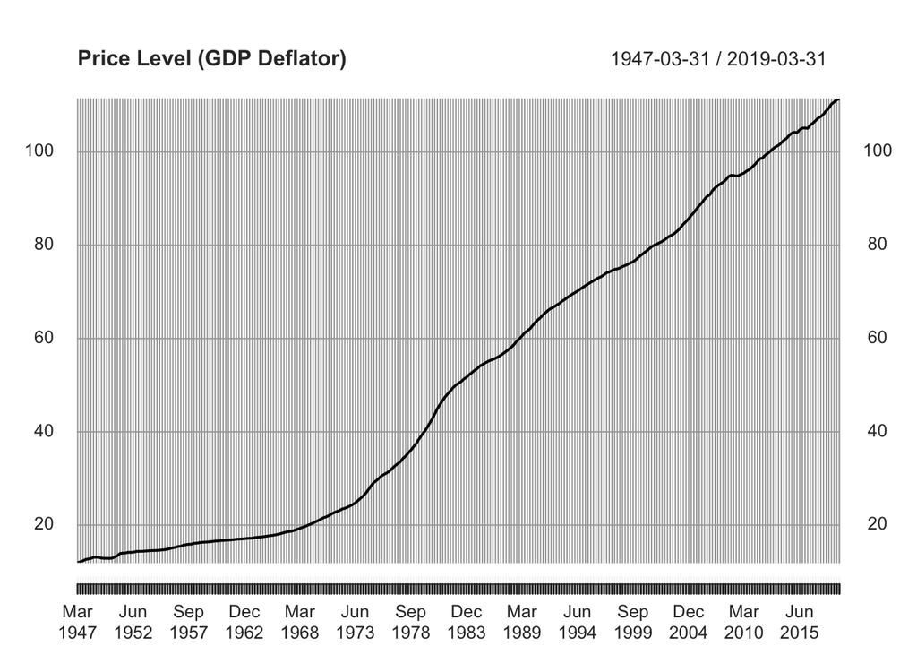

## Nonstationarity: why a big deal

- Stationarity needed for consistency and inference
- Without it, not clear what “average” or “convergence” means
- One way to think about problem it causes
  - Observations correlated with missing variable: *time*
- If both $x$ and $y$ nonstationary, have omitted variable bias
- Observe two series strongly related simply because both changing over time
- This phenomenon is known as “spurious correlation”
  - Yule (1926) called it “nonsense correlation”
  - Striking because no relationship other than the fact that variables are time series need connect them

## Example Spurious Correlation

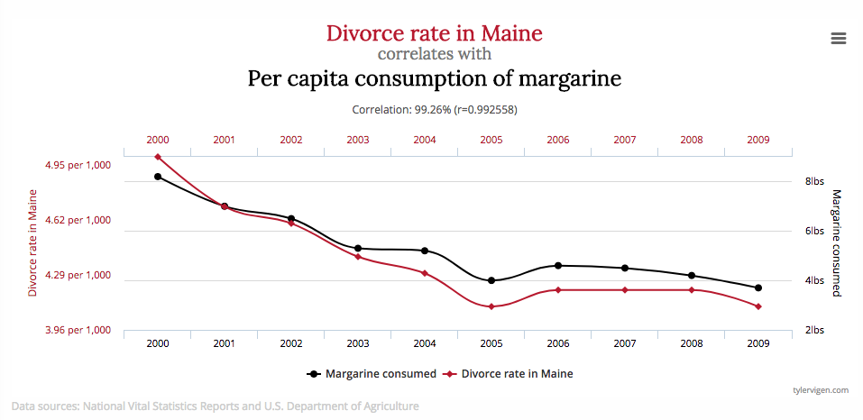

## Dealing with nonstationary data

- Running a regression using a nonstationary time series won’t produce a consistent estimate
- Tough luck for macroeconomists and forecasters
  - No reason future has to be like the past
- But there is hope, if source of nonstationarity is known
  - Transform series so that transformed series is stationary
- When mean and variance known deterministic functions of time $\mu_t$ and $\sigma_t^2$, can just normalize
  - $\frac{Y_t-\mu_t}{\sigma_t^2}$ is stationary
- In any model built out of stationary components, can solve for the stationary variable
- For random walk $Y_t=Y_{t-1}+e_t$, $Y_t$ nonstationary but $\Delta Y_t=e_t$ is stationary
- Transformed variables are stationary but regression equation may have different interpretation
  - GDP not stationary but GDP growth might be
- Differences, ratios, etc can be used

## Trend stationarity

- Simplest case is deterministic trend
  - $Y_t = \beta_0 +\beta_1 t + u_t$ for some stationary (not necessarily independent) $u_t$
- Can also do quadratic trend $\beta_0 +\beta_1 t +\beta_2 t^2$, exponential, etc
- Usually better to take logs and model as linear trend for exponentially growing series like many macroeconomic variables
- If we knew coefficients, we could just subtract trend
- Solution: put trend as covariate in regression

## Inference with time trends

- With time trends, inference is nonstandard: don’t trust, e.g. $R^2$
- It’s not stationary, so strictly speaking consistency/normality results for stationary data don’t apply, but they do still hold
- In fact, coefficient on trend converges faster than usual: for linear trend coefficient, estimation error asymptotically proportional to $\frac{1}{T^2}$ instead of $\frac{1}{T}$
- Including trend as regressor equivalent to regressing both $Y$ and $X$ on $t$, running regression on residuals
  - *Residuals* are then stationary
- Usual (or robust, if errors heteroskedastic or serially correlated) standard errors from this equivalent procedure are asymptotically valid

## Making data stationary

- Strategy of including deterministic function of time in regression generalizes
- Seasonality
  - Include dummy for month/quarter/day of week in regression to account for seasonal changes in mean
- Breaks
  - Include dummy for after/before break date
- Other approach is transforming series directly
  - Most government statistics reported already de-seasonalized
  - Can also do something like $X_t-L^4X_t$
    - Change in series over one year
  - Since both in same season, seasonal mean removed

## Summary

- With dependent data, can still learn from standard regression methods
- If data stationary and weakly dependent, have consistency and asymptotic normality
- If errors still correlated, can use robust variance estimate
- If nonstationary, can model form of nonstationarity, remove it
  - Include time trend (or season dummies, etc) in regression
  - Difference or transform data
- Once stationarity and weak dependence restored, estimation, inference, interpretation similar to iid case, with modified error estimates